# Risk Factor Analysis

## Outcome Variable

**Outcome Variable:** ever_sstunted

## Predictor Variables

**Intervention Variable:** mwtkg

**Adjustment Set:**

unadjusted

## Stratifying Variables

The analysis was stratified on these variable(s):

- agecat
- studyid
- country

## Data Summary

| agecat | studyid | country | mwtkg | ever_sstunted | n_cell | n |
| --- | --- | --- | --- | --- | --- | --- |
| 0-24 months | iLiNS-Zinc | BURKINA FASO | >=58 kg | 0 | 871 | 3216 |
| 0-24 months | iLiNS-Zinc | BURKINA FASO | >=58 kg | 1 | 66 | 3216 |
| 0-24 months | iLiNS-Zinc | BURKINA FASO | <52 kg | 0 | 1032 | 3216 |
| 0-24 months | iLiNS-Zinc | BURKINA FASO | <52 kg | 1 | 169 | 3216 |
| 0-24 months | iLiNS-Zinc | BURKINA FASO | [52-58) kg | 0 | 975 | 3216 |
| 0-24 months | iLiNS-Zinc | BURKINA FASO | [52-58) kg | 1 | 103 | 3216 |
| 0-24 months | JiVitA-3 | BANGLADESH | >=58 kg | 0 | 575 | 27196 |
| 0-24 months | JiVitA-3 | BANGLADESH | >=58 kg | 1 | 94 | 27196 |
| 0-24 months | JiVitA-3 | BANGLADESH | <52 kg | 0 | 20106 | 27196 |
| 0-24 months | JiVitA-3 | BANGLADESH | <52 kg | 1 | 4647 | 27196 |
| 0-24 months | JiVitA-3 | BANGLADESH | [52-58) kg | 0 | 1498 | 27196 |
| 0-24 months | JiVitA-3 | BANGLADESH | [52-58) kg | 1 | 276 | 27196 |
| 0-24 months | LCNI-5 | MALAWI | >=58 kg | 0 | 102 | 838 |
| 0-24 months | LCNI-5 | MALAWI | >=58 kg | 1 | 12 | 838 |
| 0-24 months | LCNI-5 | MALAWI | <52 kg | 0 | 370 | 838 |
| 0-24 months | LCNI-5 | MALAWI | <52 kg | 1 | 134 | 838 |
| 0-24 months | LCNI-5 | MALAWI | [52-58) kg | 0 | 189 | 838 |
| 0-24 months | LCNI-5 | MALAWI | [52-58) kg | 1 | 31 | 838 |
| 0-24 months | MAL-ED | BANGLADESH | >=58 kg | 0 | 45 | 254 |
| 0-24 months | MAL-ED | BANGLADESH | >=58 kg | 1 | 3 | 254 |
| 0-24 months | MAL-ED | BANGLADESH | <52 kg | 0 | 113 | 254 |
| 0-24 months | MAL-ED | BANGLADESH | <52 kg | 1 | 49 | 254 |
| 0-24 months | MAL-ED | BANGLADESH | [52-58) kg | 0 | 40 | 254 |
| 0-24 months | MAL-ED | BANGLADESH | [52-58) kg | 1 | 4 | 254 |
| 0-24 months | MAL-ED | BRAZIL | >=58 kg | 0 | 132 | 221 |
| 0-24 months | MAL-ED | BRAZIL | >=58 kg | 1 | 11 | 221 |
| 0-24 months | MAL-ED | BRAZIL | <52 kg | 0 | 38 | 221 |
| 0-24 months | MAL-ED | BRAZIL | <52 kg | 1 | 4 | 221 |
| 0-24 months | MAL-ED | BRAZIL | [52-58) kg | 0 | 30 | 221 |
| 0-24 months | MAL-ED | BRAZIL | [52-58) kg | 1 | 6 | 221 |

[output cut: 168 more lines]

The following strata were considered:

- agecat: 0-24 months, studyid: iLiNS-Zinc, country: BURKINA FASO
- agecat: 0-24 months, studyid: JiVitA-3, country: BANGLADESH
- agecat: 0-24 months, studyid: LCNI-5, country: MALAWI
- agecat: 0-24 months, studyid: MAL-ED, country: BANGLADESH
- agecat: 0-24 months, studyid: MAL-ED, country: BRAZIL
- agecat: 0-24 months, studyid: MAL-ED, country: INDIA
- agecat: 0-24 months, studyid: MAL-ED, country: NEPAL
- agecat: 0-24 months, studyid: MAL-ED, country: PERU
- agecat: 0-24 months, studyid: MAL-ED, country: SOUTH AFRICA
- agecat: 0-24 months, studyid: MAL-ED, country: TANZANIA, UNITED REPUBLIC OF
- agecat: 0-24 months, studyid: NIH-Birth, country: BANGLADESH
- agecat: 0-24 months, studyid: NIH-Crypto, country: BANGLADESH
- agecat: 0-24 months, studyid: PROBIT, country: BELARUS
- agecat: 0-24 months, studyid: PROVIDE, country: BANGLADESH
- agecat: 0-24 months, studyid: SAS-CompFeed, country: INDIA
- agecat: 0-24 months, studyid: TanzaniaChild2, country: TANZANIA, UNITED REPUBLIC OF
- agecat: 0-24 months, studyid: ZVITAMBO, country: ZIMBABWE
- agecat: 0-6 months, studyid: JiVitA-3, country: BANGLADESH
- agecat: 0-6 months, studyid: LCNI-5, country: MALAWI
- agecat: 0-6 months, studyid: MAL-ED, country: BANGLADESH
- agecat: 0-6 months, studyid: MAL-ED, country: BRAZIL
- agecat: 0-6 months, studyid: MAL-ED, country: INDIA
- agecat: 0-6 months, studyid: MAL-ED, country: NEPAL
- agecat: 0-6 months, studyid: MAL-ED, country: PERU
- agecat: 0-6 months, studyid: MAL-ED, country: SOUTH AFRICA
- agecat: 0-6 months, studyid: MAL-ED, country: TANZANIA, UNITED REPUBLIC OF
- agecat: 0-6 months, studyid: NIH-Birth, country: BANGLADESH
- agecat: 0-6 months, studyid: NIH-Crypto, country: BANGLADESH
- agecat: 0-6 months, studyid: PROBIT, country: BELARUS
- agecat: 0-6 months, studyid: PROVIDE, country: BANGLADESH
- agecat: 0-6 months, studyid: SAS-CompFeed, country: INDIA
- agecat: 0-6 months, studyid: TanzaniaChild2, country: TANZANIA, UNITED REPUBLIC OF
- agecat: 0-6 months, studyid: ZVITAMBO, country: ZIMBABWE

### Dropped Strata

Some strata were dropped due to rare outcomes:

- agecat: 0-24 months, studyid: MAL-ED, country: BANGLADESH
- agecat: 0-24 months, studyid: MAL-ED, country: BRAZIL
- agecat: 0-24 months, studyid: MAL-ED, country: NEPAL
- agecat: 0-6 months, studyid: LCNI-5, country: MALAWI
- agecat: 0-6 months, studyid: MAL-ED, country: BANGLADESH
- agecat: 0-6 months, studyid: MAL-ED, country: BRAZIL
- agecat: 0-6 months, studyid: MAL-ED, country: INDIA
- agecat: 0-6 months, studyid: MAL-ED, country: NEPAL
- agecat: 0-6 months, studyid: MAL-ED, country: SOUTH AFRICA
- agecat: 0-6 months, studyid: PROVIDE, country: BANGLADESH

## Methods Detail

We’re interested in the causal parameters $E[Y_a]$ for all values of $a \in \mathcal{A}$. These parameters represent the mean outcome if, possibly contrary to fact, we intervened to set all units to have $A=a$. Under the randomization and positivity assumptions, these are identified by the statistical parameters $\psi_a=E_W[E_{Y|A,W}(Y|A=a,W)]$. In addition, we’re interested in the mean of $Y$, $E[Y]$ under no intervention (the observed mean). We will estimate these parameters by using SuperLearner to fit the relevant likelihood factors – $E_{Y|A,W}(Y|A=a,W)$ and $p(A=a|W)$, and then updating our likelihood fit using a joint TMLE.

For unadjusted analyses ($W=\{\}$), initial likelihoods were estimated using Lrnr_glm to estimate the simple $E(Y|A)$ and Lrnr_mean to estimate $p(A)$. For adjusted analyses, a small library containing Lrnr_glmnet, Lrnr_xgboost, and Lrnr_mean was used.

Having estimated these parameters, we will then use the delta method to estimate relative risks and attributable risks relative to a prespecified baseline level of $A$.

# Results Detail

## Results Plots

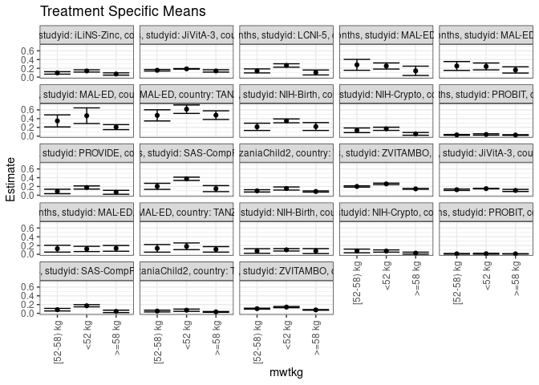

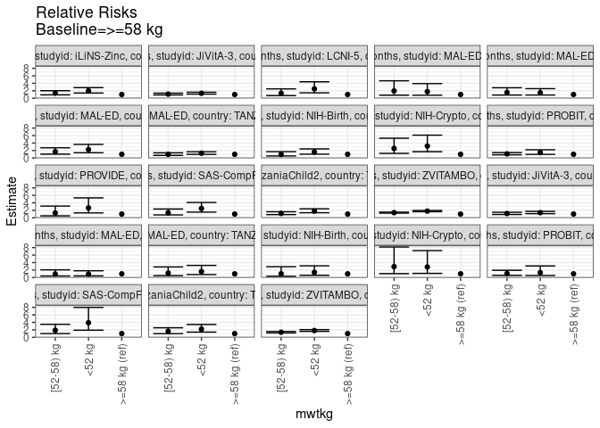

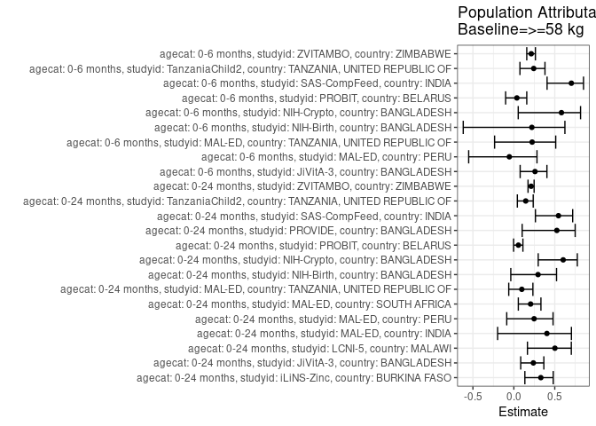

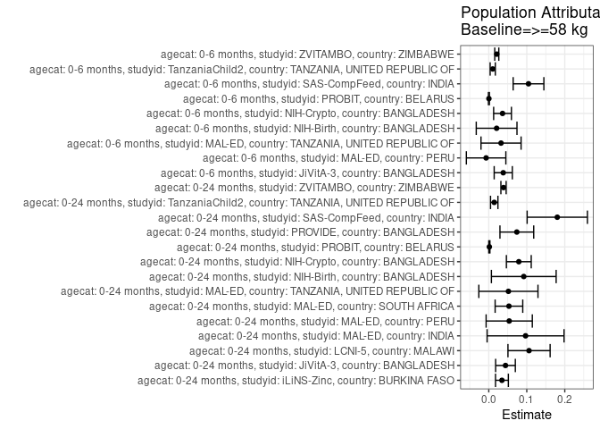

## Results Table

### Parameter: TSM

| agecat | studyid | country | intervention_level | baseline_level | estimate | ci_lower | ci_upper |
| --- | --- | --- | --- | --- | --- | --- | --- |
| 0-24 months | iLiNS-Zinc | BURKINA FASO | >=58 kg | NA | 0.0704376 | 0.0447704 | 0.0961048 |
| 0-24 months | iLiNS-Zinc | BURKINA FASO | <52 kg | NA | 0.1407161 | 0.1151957 | 0.1662364 |
| 0-24 months | iLiNS-Zinc | BURKINA FASO | [52-58) kg | NA | 0.0955473 | 0.0673099 | 0.1237847 |
| 0-24 months | JiVitA-3 | BANGLADESH | >=58 kg | NA | 0.1405082 | 0.1141173 | 0.1668992 |
| 0-24 months | JiVitA-3 | BANGLADESH | <52 kg | NA | 0.1877348 | 0.1819039 | 0.1935657 |
| 0-24 months | JiVitA-3 | BANGLADESH | [52-58) kg | NA | 0.1555806 | 0.1378229 | 0.1733383 |
| 0-24 months | LCNI-5 | MALAWI | >=58 kg | NA | 0.1052632 | 0.0488941 | 0.1616322 |
| 0-24 months | LCNI-5 | MALAWI | <52 kg | NA | 0.2658730 | 0.2272795 | 0.3044666 |
| 0-24 months | LCNI-5 | MALAWI | [52-58) kg | NA | 0.1409091 | 0.0949062 | 0.1869120 |
| 0-24 months | MAL-ED | INDIA | >=58 kg | NA | 0.1428571 | 0.0368097 | 0.2489046 |
| 0-24 months | MAL-ED | INDIA | <52 kg | NA | 0.2533333 | 0.1835886 | 0.3230780 |
| 0-24 months | MAL-ED | INDIA | [52-58) kg | NA | 0.2800000 | 0.1552882 | 0.4047118 |
| 0-24 months | MAL-ED | PERU | >=58 kg | NA | 0.1634615 | 0.0922694 | 0.2346537 |
| 0-24 months | MAL-ED | PERU | <52 kg | NA | 0.2434783 | 0.1649022 | 0.3220543 |
| 0-24 months | MAL-ED | PERU | [52-58) kg | NA | 0.2535211 | 0.1521569 | 0.3548854 |
| 0-24 months | MAL-ED | SOUTH AFRICA | >=58 kg | NA | 0.2061856 | 0.1491505 | 0.2632206 |
| 0-24 months | MAL-ED | SOUTH AFRICA | <52 kg | NA | 0.4666667 | 0.2878138 | 0.6455196 |
| 0-24 months | MAL-ED | SOUTH AFRICA | [52-58) kg | NA | 0.3478261 | 0.2099345 | 0.4857177 |
| 0-24 months | MAL-ED | TANZANIA, UNITED REPUBLIC OF | >=58 kg | NA | 0.4795918 | 0.3804874 | 0.5786962 |
| 0-24 months | MAL-ED | TANZANIA, UNITED REPUBLIC OF | <52 kg | NA | 0.6161616 | 0.5201769 | 0.7121463 |
| 0-24 months | MAL-ED | TANZANIA, UNITED REPUBLIC OF | [52-58) kg | NA | 0.4745763 | 0.3469089 | 0.6022436 |
| 0-24 months | NIH-Birth | BANGLADESH | >=58 kg | NA | 0.2195122 | 0.1298521 | 0.3091723 |
| 0-24 months | NIH-Birth | BANGLADESH | <52 kg | NA | 0.3487859 | 0.3048635 | 0.3927082 |
| 0-24 months | NIH-Birth | BANGLADESH | [52-58) kg | NA | 0.2127660 | 0.1299655 | 0.2955664 |
| 0-24 months | NIH-Crypto | BANGLADESH | >=58 kg | NA | 0.0520833 | 0.0206334 | 0.0835333 |
| 0-24 months | NIH-Crypto | BANGLADESH | <52 kg | NA | 0.1674877 | 0.1311414 | 0.2038339 |
| 0-24 months | NIH-Crypto | BANGLADESH | [52-58) kg | NA | 0.1337580 | 0.0804778 | 0.1870381 |
| 0-24 months | PROBIT | BELARUS | >=58 kg | NA | 0.0257807 | 0.0185017 | 0.0330597 |
| 0-24 months | PROBIT | BELARUS | <52 kg | NA | 0.0380195 | 0.0222839 | 0.0537550 |
| 0-24 months | PROBIT | BELARUS | [52-58) kg | NA | 0.0287892 | 0.0188879 | 0.0386904 |
| 0-24 months | PROVIDE | BANGLADESH | >=58 kg | NA | 0.0666667 | 0.0220029 | 0.1113304 |
| 0-24 months | PROVIDE | BANGLADESH | <52 kg | NA | 0.1759259 | 0.1399941 | 0.2118577 |
| 0-24 months | PROVIDE | BANGLADESH | [52-58) kg | NA | 0.0854701 | 0.0347726 | 0.1361675 |
| 0-24 months | SAS-CompFeed | INDIA | >=58 kg | NA | 0.1504425 | 0.0814564 | 0.2194285 |
| 0-24 months | SAS-CompFeed | INDIA | <52 kg | NA | 0.3750000 | 0.3377822 | 0.4122178 |
| 0-24 months | SAS-CompFeed | INDIA | [52-58) kg | NA | 0.2024793 | 0.1330970 | 0.2718617 |
| 0-24 months | TanzaniaChild2 | TANZANIA, UNITED REPUBLIC OF | >=58 kg | NA | 0.0846883 | 0.0704816 | 0.0988951 |
| 0-24 months | TanzaniaChild2 | TANZANIA, UNITED REPUBLIC OF | <52 kg | NA | 0.1526718 | 0.1171046 | 0.1882389 |
| 0-24 months | TanzaniaChild2 | TANZANIA, UNITED REPUBLIC OF | [52-58) kg | NA | 0.0993789 | 0.0726928 | 0.1260650 |
| 0-24 months | ZVITAMBO | ZIMBABWE | >=58 kg | NA | 0.1447886 | 0.1357656 | 0.1538117 |
| 0-24 months | ZVITAMBO | ZIMBABWE | <52 kg | NA | 0.2583056 | 0.2408225 | 0.2757888 |
| 0-24 months | ZVITAMBO | ZIMBABWE | [52-58) kg | NA | 0.1994582 | 0.1850452 | 0.2138712 |
| 0-6 months | JiVitA-3 | BANGLADESH | >=58 kg | NA | 0.1092814 | 0.0848668 | 0.1336961 |
| 0-6 months | JiVitA-3 | BANGLADESH | <52 kg | NA | 0.1499676 | 0.1447346 | 0.1552006 |
| 0-6 months | JiVitA-3 | BANGLADESH | [52-58) kg | NA | 0.1254237 | 0.1093192 | 0.1415282 |
| 0-6 months | MAL-ED | PERU | >=58 kg | NA | 0.1346154 | 0.0689051 | 0.2003257 |
| 0-6 months | MAL-ED | PERU | <52 kg | NA | 0.1217391 | 0.0618737 | 0.1816046 |
| 0-6 months | MAL-ED | PERU | [52-58) kg | NA | 0.1267606 | 0.0492381 | 0.2042831 |
| 0-6 months | MAL-ED | TANZANIA, UNITED REPUBLIC OF | >=58 kg | NA | 0.1122449 | 0.0496246 | 0.1748652 |
| 0-6 months | MAL-ED | TANZANIA, UNITED REPUBLIC OF | <52 kg | NA | 0.1818182 | 0.1056938 | 0.2579426 |
| 0-6 months | MAL-ED | TANZANIA, UNITED REPUBLIC OF | [52-58) kg | NA | 0.1355932 | 0.0480646 | 0.2231218 |
| 0-6 months | NIH-Birth | BANGLADESH | >=58 kg | NA | 0.0731707 | 0.0167608 | 0.1295806 |
| 0-6 months | NIH-Birth | BANGLADESH | <52 kg | NA | 0.1015453 | 0.0737083 | 0.1293823 |
| 0-6 months | NIH-Birth | BANGLADESH | [52-58) kg | NA | 0.0744681 | 0.0213539 | 0.1275823 |
| 0-6 months | NIH-Crypto | BANGLADESH | >=58 kg | NA | 0.0260417 | 0.0034998 | 0.0485835 |
| 0-6 months | NIH-Crypto | BANGLADESH | <52 kg | NA | 0.0738916 | 0.0484291 | 0.0993541 |
| 0-6 months | NIH-Crypto | BANGLADESH | [52-58) kg | NA | 0.0764331 | 0.0348458 | 0.1180205 |
| 0-6 months | PROBIT | BELARUS | >=58 kg | NA | 0.0094367 | 0.0061477 | 0.0127257 |
| 0-6 months | PROBIT | BELARUS | <52 kg | NA | 0.0123784 | 0.0018664 | 0.0228905 |
| 0-6 months | PROBIT | BELARUS | [52-58) kg | NA | 0.0101609 | 0.0032638 | 0.0170580 |
| 0-6 months | SAS-CompFeed | INDIA | >=58 kg | NA | 0.0442478 | 0.0170549 | 0.0714407 |
| 0-6 months | SAS-CompFeed | INDIA | <52 kg | NA | 0.1727116 | 0.1479652 | 0.1974580 |
| 0-6 months | SAS-CompFeed | INDIA | [52-58) kg | NA | 0.0829876 | 0.0537728 | 0.1122023 |
| 0-6 months | TanzaniaChild2 | TANZANIA, UNITED REPUBLIC OF | >=58 kg | NA | 0.0325203 | 0.0234693 | 0.0415713 |
| 0-6 months | TanzaniaChild2 | TANZANIA, UNITED REPUBLIC OF | <52 kg | NA | 0.0712468 | 0.0458092 | 0.0966845 |
| 0-6 months | TanzaniaChild2 | TANZANIA, UNITED REPUBLIC OF | [52-58) kg | NA | 0.0517598 | 0.0319982 | 0.0715215 |
| 0-6 months | ZVITAMBO | ZIMBABWE | >=58 kg | NA | 0.0781223 | 0.0712374 | 0.0850072 |
| 0-6 months | ZVITAMBO | ZIMBABWE | <52 kg | NA | 0.1417879 | 0.1278459 | 0.1557300 |
| 0-6 months | ZVITAMBO | ZIMBABWE | [52-58) kg | NA | 0.1061737 | 0.0950528 | 0.1172945 |

### Parameter: E(Y)

| agecat | studyid | country | intervention_level | baseline_level | estimate | ci_lower | ci_upper |
| --- | --- | --- | --- | --- | --- | --- | --- |
| 0-24 months | iLiNS-Zinc | BURKINA FASO | NA | NA | 0.1050995 | 0.0855497 | 0.1246493 |
| 0-24 months | JiVitA-3 | BANGLADESH | NA | NA | 0.1844757 | 0.1788759 | 0.1900754 |
| 0-24 months | LCNI-5 | MALAWI | NA | NA | 0.2112172 | 0.1835650 | 0.2388693 |
| 0-24 months | MAL-ED | INDIA | NA | NA | 0.2396694 | 0.1857746 | 0.2935643 |
| 0-24 months | MAL-ED | PERU | NA | NA | 0.2172414 | 0.1696986 | 0.2647841 |
| 0-24 months | MAL-ED | SOUTH AFRICA | NA | NA | 0.2592593 | 0.2068905 | 0.3116280 |
| 0-24 months | MAL-ED | TANZANIA, UNITED REPUBLIC OF | NA | NA | 0.5312500 | 0.4700011 | 0.5924989 |
| 0-24 months | NIH-Birth | BANGLADESH | NA | NA | 0.3116057 | 0.2753823 | 0.3478292 |
| 0-24 months | NIH-Crypto | BANGLADESH | NA | NA | 0.1311258 | 0.1070332 | 0.1552185 |
| 0-24 months | PROBIT | BELARUS | NA | NA | 0.0273018 | 0.0201306 | 0.0344729 |
| 0-24 months | PROVIDE | BANGLADESH | NA | NA | 0.1405082 | 0.1141551 | 0.1668613 |
| 0-24 months | SAS-CompFeed | INDIA | NA | NA | 0.3306931 | 0.3017014 | 0.3596847 |
| 0-24 months | TanzaniaChild2 | TANZANIA, UNITED REPUBLIC OF | NA | NA | 0.0990646 | 0.0869885 | 0.1111408 |
| 0-24 months | ZVITAMBO | ZIMBABWE | NA | NA | 0.1835951 | 0.1764261 | 0.1907642 |
| 0-6 months | JiVitA-3 | BANGLADESH | NA | NA | 0.1473645 | 0.1423155 | 0.1524136 |
| 0-6 months | MAL-ED | PERU | NA | NA | 0.1275862 | 0.0891215 | 0.1660509 |
| 0-6 months | MAL-ED | TANZANIA, UNITED REPUBLIC OF | NA | NA | 0.1445312 | 0.1013733 | 0.1876892 |
| 0-6 months | NIH-Birth | BANGLADESH | NA | NA | 0.0937997 | 0.0709973 | 0.1166021 |
| 0-6 months | NIH-Crypto | BANGLADESH | NA | NA | 0.0622517 | 0.0450059 | 0.0794974 |
| 0-6 months | PROBIT | BELARUS | NA | NA | 0.0098025 | 0.0063729 | 0.0132321 |
| 0-6 months | SAS-CompFeed | INDIA | NA | NA | 0.1488095 | 0.1307571 | 0.1668620 |
| 0-6 months | TanzaniaChild2 | TANZANIA, UNITED REPUBLIC OF | NA | NA | 0.0429422 | 0.0347475 | 0.0511369 |
| 0-6 months | ZVITAMBO | ZIMBABWE | NA | NA | 0.0991957 | 0.0936569 | 0.1047345 |

### Parameter: RR

| agecat | studyid | country | intervention_level | baseline_level | estimate | ci_lower | ci_upper |
| --- | --- | --- | --- | --- | --- | --- | --- |
| 0-24 months | iLiNS-Zinc | BURKINA FASO | >=58 kg | >=58 kg | 1.0000000 | 1.0000000 | 1.000000 |
| 0-24 months | iLiNS-Zinc | BURKINA FASO | <52 kg | >=58 kg | 1.9977418 | 1.4088761 | 2.832735 |
| 0-24 months | iLiNS-Zinc | BURKINA FASO | [52-58) kg | >=58 kg | 1.3564823 | 0.9118697 | 2.017881 |
| 0-24 months | JiVitA-3 | BANGLADESH | >=58 kg | >=58 kg | 1.0000000 | 1.0000000 | 1.000000 |
| 0-24 months | JiVitA-3 | BANGLADESH | <52 kg | >=58 kg | 1.3361127 | 1.1070826 | 1.612524 |
| 0-24 months | JiVitA-3 | BANGLADESH | [52-58) kg | >=58 kg | 1.1072705 | 0.8896356 | 1.378146 |
| 0-24 months | LCNI-5 | MALAWI | >=58 kg | >=58 kg | 1.0000000 | 1.0000000 | 1.000000 |
| 0-24 months | LCNI-5 | MALAWI | <52 kg | >=58 kg | 2.5257937 | 1.4502330 | 4.399040 |
| 0-24 months | LCNI-5 | MALAWI | [52-58) kg | >=58 kg | 1.3386364 | 0.7149623 | 2.506352 |
| 0-24 months | MAL-ED | INDIA | >=58 kg | >=58 kg | 1.0000000 | 1.0000000 | 1.000000 |
| 0-24 months | MAL-ED | INDIA | <52 kg | >=58 kg | 1.7733333 | 0.8034193 | 3.914159 |
| 0-24 months | MAL-ED | INDIA | [52-58) kg | >=58 kg | 1.9600000 | 0.8246831 | 4.658274 |
| 0-24 months | MAL-ED | PERU | >=58 kg | >=58 kg | 1.0000000 | 1.0000000 | 1.000000 |
| 0-24 months | MAL-ED | PERU | <52 kg | >=58 kg | 1.4895141 | 0.8662205 | 2.561302 |
| 0-24 months | MAL-ED | PERU | [52-58) kg | >=58 kg | 1.5509528 | 0.8586838 | 2.801327 |
| 0-24 months | MAL-ED | SOUTH AFRICA | >=58 kg | >=58 kg | 1.0000000 | 1.0000000 | 1.000000 |
| 0-24 months | MAL-ED | SOUTH AFRICA | <52 kg | >=58 kg | 2.2633333 | 1.4108361 | 3.630952 |
| 0-24 months | MAL-ED | SOUTH AFRICA | [52-58) kg | >=58 kg | 1.6869565 | 1.0403108 | 2.735550 |
| 0-24 months | MAL-ED | TANZANIA, UNITED REPUBLIC OF | >=58 kg | >=58 kg | 1.0000000 | 1.0000000 | 1.000000 |
| 0-24 months | MAL-ED | TANZANIA, UNITED REPUBLIC OF | <52 kg | >=58 kg | 1.2847625 | 0.9918251 | 1.664220 |
| 0-24 months | MAL-ED | TANZANIA, UNITED REPUBLIC OF | [52-58) kg | >=58 kg | 0.9895420 | 0.7048769 | 1.389169 |
| 0-24 months | NIH-Birth | BANGLADESH | >=58 kg | >=58 kg | 1.0000000 | 1.0000000 | 1.000000 |
| 0-24 months | NIH-Birth | BANGLADESH | <52 kg | >=58 kg | 1.5889134 | 1.0362693 | 2.436284 |
| 0-24 months | NIH-Birth | BANGLADESH | [52-58) kg | >=58 kg | 0.9692671 | 0.5513542 | 1.703948 |
| 0-24 months | NIH-Crypto | BANGLADESH | >=58 kg | >=58 kg | 1.0000000 | 1.0000000 | 1.000000 |
| 0-24 months | NIH-Crypto | BANGLADESH | <52 kg | >=58 kg | 3.2157635 | 1.6928533 | 6.108701 |
| 0-24 months | NIH-Crypto | BANGLADESH | [52-58) kg | >=58 kg | 2.5681529 | 1.2458263 | 5.294004 |
| 0-24 months | PROBIT | BELARUS | >=58 kg | >=58 kg | 1.0000000 | 1.0000000 | 1.000000 |
| 0-24 months | PROBIT | BELARUS | <52 kg | >=58 kg | 1.4747243 | 0.9870047 | 2.203446 |
| 0-24 months | PROBIT | BELARUS | [52-58) kg | >=58 kg | 1.1166936 | 0.8588952 | 1.451870 |
| 0-24 months | PROVIDE | BANGLADESH | >=58 kg | >=58 kg | 1.0000000 | 1.0000000 | 1.000000 |
| 0-24 months | PROVIDE | BANGLADESH | <52 kg | >=58 kg | 2.6388889 | 1.3099126 | 5.316183 |
| 0-24 months | PROVIDE | BANGLADESH | [52-58) kg | >=58 kg | 1.2820513 | 0.5239569 | 3.137005 |
| 0-24 months | SAS-CompFeed | INDIA | >=58 kg | >=58 kg | 1.0000000 | 1.0000000 | 1.000000 |
| 0-24 months | SAS-CompFeed | INDIA | <52 kg | >=58 kg | 2.4926471 | 1.5194763 | 4.089099 |
| 0-24 months | SAS-CompFeed | INDIA | [52-58) kg | >=58 kg | 1.3458921 | 0.7711195 | 2.349085 |
| 0-24 months | TanzaniaChild2 | TANZANIA, UNITED REPUBLIC OF | >=58 kg | >=58 kg | 1.0000000 | 1.0000000 | 1.000000 |
| 0-24 months | TanzaniaChild2 | TANZANIA, UNITED REPUBLIC OF | <52 kg | >=58 kg | 1.8027481 | 1.3528782 | 2.402212 |
| 0-24 months | TanzaniaChild2 | TANZANIA, UNITED REPUBLIC OF | [52-58) kg | >=58 kg | 1.1734658 | 0.8549954 | 1.610561 |
| 0-24 months | ZVITAMBO | ZIMBABWE | >=58 kg | >=58 kg | 1.0000000 | 1.0000000 | 1.000000 |
| 0-24 months | ZVITAMBO | ZIMBABWE | <52 kg | >=58 kg | 1.7840188 | 1.6272063 | 1.955943 |
| 0-24 months | ZVITAMBO | ZIMBABWE | [52-58) kg | >=58 kg | 1.3775817 | 1.2522078 | 1.515508 |
| 0-6 months | JiVitA-3 | BANGLADESH | >=58 kg | >=58 kg | 1.0000000 | 1.0000000 | 1.000000 |
| 0-6 months | JiVitA-3 | BANGLADESH | <52 kg | >=58 kg | 1.3723063 | 1.0978853 | 1.715320 |
| 0-6 months | JiVitA-3 | BANGLADESH | [52-58) kg | >=58 kg | 1.1477130 | 0.8903921 | 1.479399 |
| 0-6 months | MAL-ED | PERU | >=58 kg | >=58 kg | 1.0000000 | 1.0000000 | 1.000000 |
| 0-6 months | MAL-ED | PERU | <52 kg | >=58 kg | 0.9043478 | 0.4522910 | 1.808228 |
| 0-6 months | MAL-ED | PERU | [52-58) kg | >=58 kg | 0.9416499 | 0.4305852 | 2.059301 |
| 0-6 months | MAL-ED | TANZANIA, UNITED REPUBLIC OF | >=58 kg | >=58 kg | 1.0000000 | 1.0000000 | 1.000000 |
| 0-6 months | MAL-ED | TANZANIA, UNITED REPUBLIC OF | <52 kg | >=58 kg | 1.6198347 | 0.8063817 | 3.253874 |
| 0-6 months | MAL-ED | TANZANIA, UNITED REPUBLIC OF | [52-58) kg | >=58 kg | 1.2080123 | 0.5146756 | 2.835366 |
| 0-6 months | NIH-Birth | BANGLADESH | >=58 kg | >=58 kg | 1.0000000 | 1.0000000 | 1.000000 |
| 0-6 months | NIH-Birth | BANGLADESH | <52 kg | >=58 kg | 1.3877851 | 0.6123111 | 3.145374 |
| 0-6 months | NIH-Birth | BANGLADESH | [52-58) kg | >=58 kg | 1.0177305 | 0.3560469 | 2.909098 |
| 0-6 months | NIH-Crypto | BANGLADESH | >=58 kg | >=58 kg | 1.0000000 | 1.0000000 | 1.000000 |
| 0-6 months | NIH-Crypto | BANGLADESH | <52 kg | >=58 kg | 2.8374384 | 1.1176468 | 7.203579 |
| 0-6 months | NIH-Crypto | BANGLADESH | [52-58) kg | >=58 kg | 2.9350318 | 1.0558100 | 8.159055 |
| 0-6 months | PROBIT | BELARUS | >=58 kg | >=58 kg | 1.0000000 | 1.0000000 | 1.000000 |
| 0-6 months | PROBIT | BELARUS | <52 kg | >=58 kg | 1.3117303 | 0.5542936 | 3.104197 |
| 0-6 months | PROBIT | BELARUS | [52-58) kg | >=58 kg | 1.0767391 | 0.5963646 | 1.944057 |
| 0-6 months | SAS-CompFeed | INDIA | >=58 kg | >=58 kg | 1.0000000 | 1.0000000 | 1.000000 |
| 0-6 months | SAS-CompFeed | INDIA | <52 kg | >=58 kg | 3.9032815 | 1.9049723 | 7.997810 |
| 0-6 months | SAS-CompFeed | INDIA | [52-58) kg | >=58 kg | 1.8755187 | 1.0096478 | 3.483958 |
| 0-6 months | TanzaniaChild2 | TANZANIA, UNITED REPUBLIC OF | >=58 kg | >=58 kg | 1.0000000 | 1.0000000 | 1.000000 |
| 0-6 months | TanzaniaChild2 | TANZANIA, UNITED REPUBLIC OF | <52 kg | >=58 kg | 2.1908397 | 1.3931777 | 3.445202 |
| 0-6 months | TanzaniaChild2 | TANZANIA, UNITED REPUBLIC OF | [52-58) kg | >=58 kg | 1.5916149 | 0.9923091 | 2.552872 |
| 0-6 months | ZVITAMBO | ZIMBABWE | >=58 kg | >=58 kg | 1.0000000 | 1.0000000 | 1.000000 |
| 0-6 months | ZVITAMBO | ZIMBABWE | <52 kg | >=58 kg | 1.8149478 | 1.5904428 | 2.071144 |
| 0-6 months | ZVITAMBO | ZIMBABWE | [52-58) kg | >=58 kg | 1.3590696 | 1.1852034 | 1.558442 |

### Parameter: PAR

| agecat | studyid | country | intervention_level | baseline_level | estimate | ci_lower | ci_upper |
| --- | --- | --- | --- | --- | --- | --- | --- |
| 0-24 months | iLiNS-Zinc | BURKINA FASO | >=58 kg | NA | 0.0346619 | 0.0177576 | 0.0515663 |
| 0-24 months | JiVitA-3 | BANGLADESH | >=58 kg | NA | 0.0439674 | 0.0180641 | 0.0698708 |
| 0-24 months | LCNI-5 | MALAWI | >=58 kg | NA | 0.1059540 | 0.0504779 | 0.1614301 |
| 0-24 months | MAL-ED | INDIA | >=58 kg | NA | 0.0968123 | -0.0044158 | 0.1980403 |
| 0-24 months | MAL-ED | PERU | >=58 kg | NA | 0.0537798 | -0.0069937 | 0.1145534 |
| 0-24 months | MAL-ED | SOUTH AFRICA | >=58 kg | NA | 0.0530737 | 0.0167308 | 0.0894166 |
| 0-24 months | MAL-ED | TANZANIA, UNITED REPUBLIC OF | >=58 kg | NA | 0.0516582 | -0.0261453 | 0.1294616 |
| 0-24 months | NIH-Birth | BANGLADESH | >=58 kg | NA | 0.0920935 | 0.0069169 | 0.1772702 |
| 0-24 months | NIH-Crypto | BANGLADESH | >=58 kg | NA | 0.0790425 | 0.0463853 | 0.1116997 |
| 0-24 months | PROBIT | BELARUS | >=58 kg | NA | 0.0015211 | 0.0000099 | 0.0030323 |
| 0-24 months | PROVIDE | BANGLADESH | >=58 kg | NA | 0.0738416 | 0.0294153 | 0.1182678 |
| 0-24 months | SAS-CompFeed | INDIA | >=58 kg | NA | 0.1802506 | 0.1009280 | 0.2595731 |
| 0-24 months | TanzaniaChild2 | TANZANIA, UNITED REPUBLIC OF | >=58 kg | NA | 0.0143763 | 0.0046631 | 0.0240894 |
| 0-24 months | ZVITAMBO | ZIMBABWE | >=58 kg | NA | 0.0388065 | 0.0318860 | 0.0457270 |
| 0-6 months | JiVitA-3 | BANGLADESH | >=58 kg | NA | 0.0380831 | 0.0142116 | 0.0619546 |
| 0-6 months | MAL-ED | PERU | >=58 kg | NA | -0.0070292 | -0.0589949 | 0.0449366 |
| 0-6 months | MAL-ED | TANZANIA, UNITED REPUBLIC OF | >=58 kg | NA | 0.0322864 | -0.0204551 | 0.0850278 |
| 0-6 months | NIH-Birth | BANGLADESH | >=58 kg | NA | 0.0206290 | -0.0329654 | 0.0742233 |
| 0-6 months | NIH-Crypto | BANGLADESH | >=58 kg | NA | 0.0362100 | 0.0128197 | 0.0596003 |
| 0-6 months | PROBIT | BELARUS | >=58 kg | NA | 0.0003658 | -0.0009275 | 0.0016590 |
| 0-6 months | SAS-CompFeed | INDIA | >=58 kg | NA | 0.1045617 | 0.0641514 | 0.1449721 |
| 0-6 months | TanzaniaChild2 | TANZANIA, UNITED REPUBLIC OF | >=58 kg | NA | 0.0104219 | 0.0036207 | 0.0172230 |
| 0-6 months | ZVITAMBO | ZIMBABWE | >=58 kg | NA | 0.0210734 | 0.0157229 | 0.0264239 |

### Parameter: PAF

| agecat | studyid | country | intervention_level | baseline_level | estimate | ci_lower | ci_upper |
| --- | --- | --- | --- | --- | --- | --- | --- |
| 0-24 months | iLiNS-Zinc | BURKINA FASO | >=58 kg | NA | 0.3298011 | 0.1345557 | 0.4809989 |
| 0-24 months | JiVitA-3 | BANGLADESH | >=58 kg | NA | 0.2383373 | 0.0840961 | 0.3666038 |
| 0-24 months | LCNI-5 | MALAWI | >=58 kg | NA | 0.5016354 | 0.1660818 | 0.7021684 |
| 0-24 months | MAL-ED | INDIA | >=58 kg | NA | 0.4039409 | -0.1982678 | 0.7034999 |
| 0-24 months | MAL-ED | PERU | >=58 kg | NA | 0.2475580 | -0.0868432 | 0.4790702 |
| 0-24 months | MAL-ED | SOUTH AFRICA | >=58 kg | NA | 0.2047128 | 0.0546706 | 0.3309404 |
| 0-24 months | MAL-ED | TANZANIA, UNITED REPUBLIC OF | >=58 kg | NA | 0.0972389 | -0.0622908 | 0.2328112 |
| 0-24 months | NIH-Birth | BANGLADESH | >=58 kg | NA | 0.2955450 | -0.0372617 | 0.5215703 |
| 0-24 months | NIH-Crypto | BANGLADESH | >=58 kg | NA | 0.6027988 | 0.2977533 | 0.7753371 |
| 0-24 months | PROBIT | BELARUS | >=58 kg | NA | 0.0557126 | -0.0028073 | 0.1108175 |
| 0-24 months | PROVIDE | BANGLADESH | >=58 kg | NA | 0.5255319 | 0.1015731 | 0.7494287 |
| 0-24 months | SAS-CompFeed | INDIA | >=58 kg | NA | 0.5450692 | 0.2636676 | 0.7189285 |
| 0-24 months | TanzaniaChild2 | TANZANIA, UNITED REPUBLIC OF | >=58 kg | NA | 0.1451202 | 0.0426894 | 0.2365911 |
| 0-24 months | ZVITAMBO | ZIMBABWE | >=58 kg | NA | 0.2113700 | 0.1733765 | 0.2476173 |
| 0-6 months | JiVitA-3 | BANGLADESH | >=58 kg | NA | 0.2584279 | 0.0770496 | 0.4041617 |
| 0-6 months | MAL-ED | PERU | >=58 kg | NA | -0.0550936 | -0.5518361 | 0.2826418 |
| 0-6 months | MAL-ED | TANZANIA, UNITED REPUBLIC OF | >=58 kg | NA | 0.2233867 | -0.2352083 | 0.5117193 |
| 0-6 months | NIH-Birth | BANGLADESH | >=58 kg | NA | 0.2199256 | -0.6183339 | 0.6239861 |
| 0-6 months | NIH-Crypto | BANGLADESH | >=58 kg | NA | 0.5816711 | 0.0535431 | 0.8151009 |
| 0-6 months | PROBIT | BELARUS | >=58 kg | NA | 0.0373152 | -0.1003688 | 0.1577714 |
| 0-6 months | SAS-CompFeed | INDIA | >=58 kg | NA | 0.7026549 | 0.4061002 | 0.8511295 |
| 0-6 months | TanzaniaChild2 | TANZANIA, UNITED REPUBLIC OF | >=58 kg | NA | 0.2426950 | 0.0744456 | 0.3803597 |
| 0-6 months | ZVITAMBO | ZIMBABWE | >=58 kg | NA | 0.2124425 | 0.1577792 | 0.2635580 |